# Risk Factor Analysis

## Outcome Variable

**Outcome Variable:** ever_swasted

## Predictor Variables

**Intervention Variable:** nrooms

**Adjustment Set:**

- arm
- sex
- W_mage
- meducyrs
- feducyrs
- hhwealth_quart
- hfoodsec
- W_mhtcm
- W_nchldlt5
- W_parity
- impfloor
- impsan
- safeh20
- delta_W_mage
- delta_meducyrs
- delta_feducyrs
- delta_hhwealth_quart
- delta_hfoodsec
- delta_W_mhtcm
- delta_W_nchldlt5
- delta_W_parity
- delta_impfloor
- delta_impsan
- delta_safeh20

## Stratifying Variables

The analysis was stratified on these variable(s):

- agecat
- studyid
- country

## Data Summary

| agecat | studyid | country | nrooms | ever_swasted | n_cell | n |
| --- | --- | --- | --- | --- | --- | --- |
| 0-24 months | ki0047075b-MAL-ED | BANGLADESH | 4+ | 0 | 11 | 242 |
| 0-24 months | ki0047075b-MAL-ED | BANGLADESH | 4+ | 1 | 1 | 242 |
| 0-24 months | ki0047075b-MAL-ED | BANGLADESH | 1 | 0 | 135 | 242 |
| 0-24 months | ki0047075b-MAL-ED | BANGLADESH | 1 | 1 | 17 | 242 |
| 0-24 months | ki0047075b-MAL-ED | BANGLADESH | 2 | 0 | 48 | 242 |
| 0-24 months | ki0047075b-MAL-ED | BANGLADESH | 2 | 1 | 2 | 242 |
| 0-24 months | ki0047075b-MAL-ED | BANGLADESH | 3 | 0 | 27 | 242 |
| 0-24 months | ki0047075b-MAL-ED | BANGLADESH | 3 | 1 | 1 | 242 |
| 0-24 months | ki0047075b-MAL-ED | BRAZIL | 4+ | 0 | 124 | 210 |
| 0-24 months | ki0047075b-MAL-ED | BRAZIL | 4+ | 1 | 3 | 210 |
| 0-24 months | ki0047075b-MAL-ED | BRAZIL | 1 | 0 | 4 | 210 |
| 0-24 months | ki0047075b-MAL-ED | BRAZIL | 1 | 1 | 0 | 210 |
| 0-24 months | ki0047075b-MAL-ED | BRAZIL | 2 | 0 | 20 | 210 |
| 0-24 months | ki0047075b-MAL-ED | BRAZIL | 2 | 1 | 0 | 210 |
| 0-24 months | ki0047075b-MAL-ED | BRAZIL | 3 | 0 | 58 | 210 |
| 0-24 months | ki0047075b-MAL-ED | BRAZIL | 3 | 1 | 1 | 210 |
| 0-24 months | ki0047075b-MAL-ED | INDIA | 4+ | 0 | 23 | 235 |
| 0-24 months | ki0047075b-MAL-ED | INDIA | 4+ | 1 | 2 | 235 |
| 0-24 months | ki0047075b-MAL-ED | INDIA | 1 | 0 | 73 | 235 |
| 0-24 months | ki0047075b-MAL-ED | INDIA | 1 | 1 | 11 | 235 |
| 0-24 months | ki0047075b-MAL-ED | INDIA | 2 | 0 | 72 | 235 |
| 0-24 months | ki0047075b-MAL-ED | INDIA | 2 | 1 | 6 | 235 |
| 0-24 months | ki0047075b-MAL-ED | INDIA | 3 | 0 | 44 | 235 |
| 0-24 months | ki0047075b-MAL-ED | INDIA | 3 | 1 | 4 | 235 |
| 0-24 months | ki0047075b-MAL-ED | NEPAL | 4+ | 0 | 126 | 236 |
| 0-24 months | ki0047075b-MAL-ED | NEPAL | 4+ | 1 | 5 | 236 |
| 0-24 months | ki0047075b-MAL-ED | NEPAL | 1 | 0 | 48 | 236 |
| 0-24 months | ki0047075b-MAL-ED | NEPAL | 1 | 1 | 4 | 236 |
| 0-24 months | ki0047075b-MAL-ED | NEPAL | 2 | 0 | 31 | 236 |
| 0-24 months | ki0047075b-MAL-ED | NEPAL | 2 | 1 | 0 | 236 |

[output cut: 354 more lines]

The following strata were considered:

- agecat: 0-24 months, studyid: ki0047075b-MAL-ED, country: BANGLADESH
- agecat: 0-24 months, studyid: ki0047075b-MAL-ED, country: BRAZIL
- agecat: 0-24 months, studyid: ki0047075b-MAL-ED, country: INDIA
- agecat: 0-24 months, studyid: ki0047075b-MAL-ED, country: NEPAL
- agecat: 0-24 months, studyid: ki0047075b-MAL-ED, country: PERU
- agecat: 0-24 months, studyid: ki0047075b-MAL-ED, country: SOUTH AFRICA
- agecat: 0-24 months, studyid: ki0047075b-MAL-ED, country: TANZANIA, UNITED REPUBLIC OF
- agecat: 0-24 months, studyid: ki1000108-CMC-V-BCS-2002, country: INDIA
- agecat: 0-24 months, studyid: ki1000108-IRC, country: INDIA
- agecat: 0-24 months, studyid: ki1017093b-PROVIDE, country: BANGLADESH
- agecat: 0-24 months, studyid: ki1017093c-NIH-Crypto, country: BANGLADESH
- agecat: 0-24 months, studyid: ki1113344-GMS-Nepal, country: NEPAL
- agecat: 0-24 months, studyid: ki1114097-CONTENT, country: PERU
- agecat: 0-24 months, studyid: ki1135781-COHORTS, country: INDIA
- agecat: 0-24 months, studyid: kiGH5241-JiVitA-3, country: BANGLADESH
- agecat: 0-24 months, studyid: kiGH5241-JiVitA-4, country: BANGLADESH
- agecat: 0-6 months, studyid: ki0047075b-MAL-ED, country: BANGLADESH
- agecat: 0-6 months, studyid: ki0047075b-MAL-ED, country: BRAZIL
- agecat: 0-6 months, studyid: ki0047075b-MAL-ED, country: INDIA
- agecat: 0-6 months, studyid: ki0047075b-MAL-ED, country: NEPAL
- agecat: 0-6 months, studyid: ki0047075b-MAL-ED, country: PERU
- agecat: 0-6 months, studyid: ki0047075b-MAL-ED, country: SOUTH AFRICA
- agecat: 0-6 months, studyid: ki0047075b-MAL-ED, country: TANZANIA, UNITED REPUBLIC OF
- agecat: 0-6 months, studyid: ki1000108-CMC-V-BCS-2002, country: INDIA
- agecat: 0-6 months, studyid: ki1000108-IRC, country: INDIA
- agecat: 0-6 months, studyid: ki1017093b-PROVIDE, country: BANGLADESH
- agecat: 0-6 months, studyid: ki1017093c-NIH-Crypto, country: BANGLADESH
- agecat: 0-6 months, studyid: ki1113344-GMS-Nepal, country: NEPAL
- agecat: 0-6 months, studyid: ki1114097-CONTENT, country: PERU
- agecat: 0-6 months, studyid: ki1135781-COHORTS, country: INDIA
- agecat: 0-6 months, studyid: kiGH5241-JiVitA-3, country: BANGLADESH
- agecat: 0-6 months, studyid: kiGH5241-JiVitA-4, country: BANGLADESH
- agecat: 6-24 months, studyid: ki0047075b-MAL-ED, country: BANGLADESH
- agecat: 6-24 months, studyid: ki0047075b-MAL-ED, country: BRAZIL
- agecat: 6-24 months, studyid: ki0047075b-MAL-ED, country: INDIA
- agecat: 6-24 months, studyid: ki0047075b-MAL-ED, country: NEPAL
- agecat: 6-24 months, studyid: ki0047075b-MAL-ED, country: PERU
- agecat: 6-24 months, studyid: ki0047075b-MAL-ED, country: SOUTH AFRICA
- agecat: 6-24 months, studyid: ki0047075b-MAL-ED, country: TANZANIA, UNITED REPUBLIC OF
- agecat: 6-24 months, studyid: ki1000108-CMC-V-BCS-2002, country: INDIA
- agecat: 6-24 months, studyid: ki1000108-IRC, country: INDIA
- agecat: 6-24 months, studyid: ki1017093b-PROVIDE, country: BANGLADESH
- agecat: 6-24 months, studyid: ki1017093c-NIH-Crypto, country: BANGLADESH
- agecat: 6-24 months, studyid: ki1113344-GMS-Nepal, country: NEPAL
- agecat: 6-24 months, studyid: ki1114097-CONTENT, country: PERU
- agecat: 6-24 months, studyid: ki1135781-COHORTS, country: INDIA
- agecat: 6-24 months, studyid: kiGH5241-JiVitA-3, country: BANGLADESH
- agecat: 6-24 months, studyid: kiGH5241-JiVitA-4, country: BANGLADESH

### Dropped Strata

Some strata were dropped due to rare outcomes:

- agecat: 0-24 months, studyid: ki0047075b-MAL-ED, country: BANGLADESH
- agecat: 0-24 months, studyid: ki0047075b-MAL-ED, country: BRAZIL
- agecat: 0-24 months, studyid: ki0047075b-MAL-ED, country: INDIA
- agecat: 0-24 months, studyid: ki0047075b-MAL-ED, country: NEPAL
- agecat: 0-24 months, studyid: ki0047075b-MAL-ED, country: PERU
- agecat: 0-24 months, studyid: ki0047075b-MAL-ED, country: SOUTH AFRICA
- agecat: 0-24 months, studyid: ki0047075b-MAL-ED, country: TANZANIA, UNITED REPUBLIC OF
- agecat: 0-24 months, studyid: ki1000108-CMC-V-BCS-2002, country: INDIA
- agecat: 0-24 months, studyid: ki1017093b-PROVIDE, country: BANGLADESH
- agecat: 0-24 months, studyid: ki1114097-CONTENT, country: PERU
- agecat: 0-6 months, studyid: ki0047075b-MAL-ED, country: BANGLADESH
- agecat: 0-6 months, studyid: ki0047075b-MAL-ED, country: BRAZIL
- agecat: 0-6 months, studyid: ki0047075b-MAL-ED, country: INDIA
- agecat: 0-6 months, studyid: ki0047075b-MAL-ED, country: NEPAL
- agecat: 0-6 months, studyid: ki0047075b-MAL-ED, country: PERU
- agecat: 0-6 months, studyid: ki0047075b-MAL-ED, country: SOUTH AFRICA
- agecat: 0-6 months, studyid: ki0047075b-MAL-ED, country: TANZANIA, UNITED REPUBLIC OF
- agecat: 0-6 months, studyid: ki1000108-CMC-V-BCS-2002, country: INDIA
- agecat: 0-6 months, studyid: ki1017093b-PROVIDE, country: BANGLADESH
- agecat: 0-6 months, studyid: ki1113344-GMS-Nepal, country: NEPAL
- agecat: 0-6 months, studyid: ki1114097-CONTENT, country: PERU
- agecat: 6-24 months, studyid: ki0047075b-MAL-ED, country: BANGLADESH
- agecat: 6-24 months, studyid: ki0047075b-MAL-ED, country: BRAZIL
- agecat: 6-24 months, studyid: ki0047075b-MAL-ED, country: INDIA
- agecat: 6-24 months, studyid: ki0047075b-MAL-ED, country: NEPAL
- agecat: 6-24 months, studyid: ki0047075b-MAL-ED, country: PERU
- agecat: 6-24 months, studyid: ki0047075b-MAL-ED, country: SOUTH AFRICA
- agecat: 6-24 months, studyid: ki0047075b-MAL-ED, country: TANZANIA, UNITED REPUBLIC OF
- agecat: 6-24 months, studyid: ki1000108-CMC-V-BCS-2002, country: INDIA
- agecat: 6-24 months, studyid: ki1000108-IRC, country: INDIA
- agecat: 6-24 months, studyid: ki1017093b-PROVIDE, country: BANGLADESH
- agecat: 6-24 months, studyid: ki1017093c-NIH-Crypto, country: BANGLADESH
- agecat: 6-24 months, studyid: ki1114097-CONTENT, country: PERU
- agecat: 6-24 months, studyid: ki1135781-COHORTS, country: INDIA

## Methods Detail

We’re interested in the causal parameters $E[Y_a]$ for all values of $a \in \mathcal{A}$. These parameters represent the mean outcome if, possibly contrary to fact, we intervened to set all units to have $A=a$. Under the randomization and positivity assumptions, these are identified by the statistical parameters $\psi_a=E_W[E_{Y|A,W}(Y|A=a,W)]$. In addition, we’re interested in the mean of $Y$, $E[Y]$ under no intervention (the observed mean). We will estimate these parameters by using SuperLearner to fit the relevant likelihood factors – $E_{Y|A,W}(Y|A=a,W)$ and $p(A=a|W)$, and then updating our likelihood fit using a joint TMLE.

For unadjusted analyses ($W=\{\}$), initial likelihoods were estimated using Lrnr_glm to estimate the simple $E(Y|A)$ and Lrnr_mean to estimate $p(A)$. For adjusted analyses, a small library containing Lrnr_glmnet, Lrnr_xgboost, and Lrnr_mean was used.

Having estimated these parameters, we will then use the delta method to estimate relative risks and attributable risks relative to a prespecified baseline level of $A$.

# Results Detail

## Results Plots

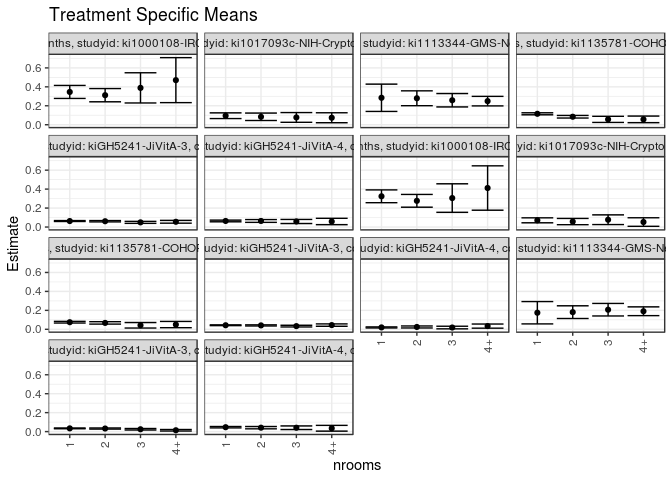

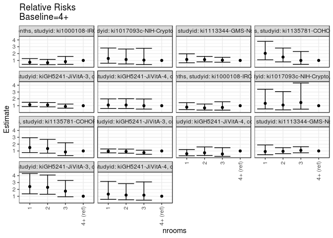

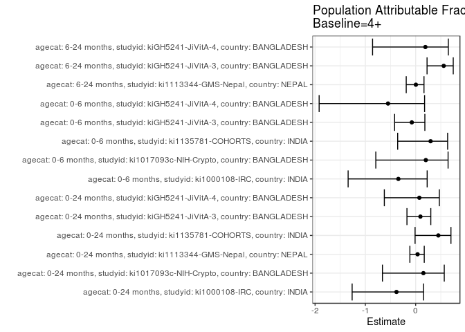

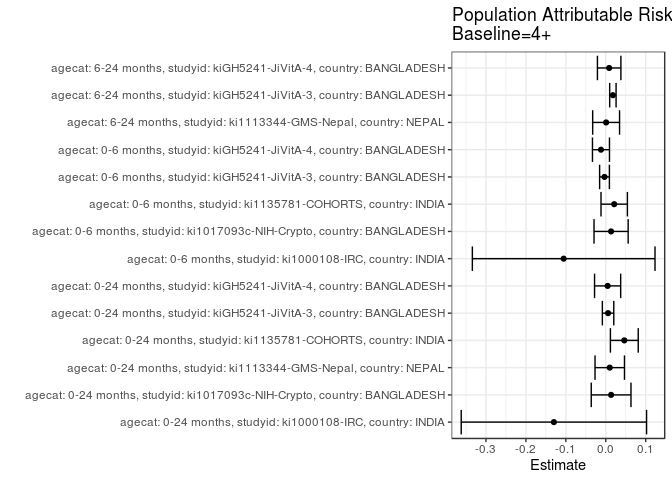

## Results Table

### Parameter: TSM

| agecat | studyid | country | intervention_level | baseline_level | estimate | ci_lower | ci_upper |
| --- | --- | --- | --- | --- | --- | --- | --- |
| 0-24 months | ki1000108-IRC | INDIA | 4+ | NA | 0.4705882 | 0.2330280 | 0.7081485 |
| 0-24 months | ki1000108-IRC | INDIA | 1 | NA | 0.3459459 | 0.2773172 | 0.4145747 |
| 0-24 months | ki1000108-IRC | INDIA | 2 | NA | 0.3117647 | 0.2420477 | 0.3814817 |
| 0-24 months | ki1000108-IRC | INDIA | 3 | NA | 0.3888889 | 0.2294469 | 0.5483308 |
| 0-24 months | ki1017093c-NIH-Crypto | BANGLADESH | 4+ | NA | 0.0736842 | 0.0211140 | 0.1262544 |
| 0-24 months | ki1017093c-NIH-Crypto | BANGLADESH | 1 | NA | 0.0951087 | 0.0651157 | 0.1251016 |
| 0-24 months | ki1017093c-NIH-Crypto | BANGLADESH | 2 | NA | 0.0837696 | 0.0444541 | 0.1230851 |
| 0-24 months | ki1017093c-NIH-Crypto | BANGLADESH | 3 | NA | 0.0769231 | 0.0256764 | 0.1281697 |
| 0-24 months | ki1113344-GMS-Nepal | NEPAL | 4+ | NA | 0.2491555 | 0.1988754 | 0.2994355 |
| 0-24 months | ki1113344-GMS-Nepal | NEPAL | 1 | NA | 0.2843213 | 0.1402604 | 0.4283823 |
| 0-24 months | ki1113344-GMS-Nepal | NEPAL | 2 | NA | 0.2792557 | 0.2010005 | 0.3575109 |
| 0-24 months | ki1113344-GMS-Nepal | NEPAL | 3 | NA | 0.2585138 | 0.1877752 | 0.3292523 |
| 0-24 months | ki1135781-COHORTS | INDIA | 4+ | NA | 0.0566038 | 0.0218405 | 0.0913670 |
| 0-24 months | ki1135781-COHORTS | INDIA | 1 | NA | 0.1153518 | 0.1047843 | 0.1259192 |
| 0-24 months | ki1135781-COHORTS | INDIA | 2 | NA | 0.0842986 | 0.0704836 | 0.0981136 |
| 0-24 months | ki1135781-COHORTS | INDIA | 3 | NA | 0.0564103 | 0.0240254 | 0.0887951 |
| 0-24 months | kiGH5241-JiVitA-3 | BANGLADESH | 4+ | NA | 0.0552051 | 0.0405812 | 0.0698289 |
| 0-24 months | kiGH5241-JiVitA-3 | BANGLADESH | 1 | NA | 0.0629351 | 0.0581489 | 0.0677213 |
| 0-24 months | kiGH5241-JiVitA-3 | BANGLADESH | 2 | NA | 0.0609828 | 0.0541100 | 0.0678556 |
| 0-24 months | kiGH5241-JiVitA-3 | BANGLADESH | 3 | NA | 0.0491040 | 0.0386790 | 0.0595290 |
| 0-24 months | kiGH5241-JiVitA-4 | BANGLADESH | 4+ | NA | 0.0584006 | 0.0247301 | 0.0920711 |
| 0-24 months | kiGH5241-JiVitA-4 | BANGLADESH | 1 | NA | 0.0638733 | 0.0551535 | 0.0725930 |
| 0-24 months | kiGH5241-JiVitA-4 | BANGLADESH | 2 | NA | 0.0638374 | 0.0491224 | 0.0785523 |
| 0-24 months | kiGH5241-JiVitA-4 | BANGLADESH | 3 | NA | 0.0584970 | 0.0368344 | 0.0801596 |
| 0-6 months | ki1000108-IRC | INDIA | 4+ | NA | 0.4117647 | 0.1775271 | 0.6460023 |
| 0-6 months | ki1000108-IRC | INDIA | 1 | NA | 0.3243243 | 0.2567854 | 0.3918632 |
| 0-6 months | ki1000108-IRC | INDIA | 2 | NA | 0.2764706 | 0.2091560 | 0.3437852 |
| 0-6 months | ki1000108-IRC | INDIA | 3 | NA | 0.3055556 | 0.1548971 | 0.4562140 |
| 0-6 months | ki1017093c-NIH-Crypto | BANGLADESH | 4+ | NA | 0.0526316 | 0.0076996 | 0.0975636 |
| 0-6 months | ki1017093c-NIH-Crypto | BANGLADESH | 1 | NA | 0.0706522 | 0.0444545 | 0.0968498 |
| 0-6 months | ki1017093c-NIH-Crypto | BANGLADESH | 2 | NA | 0.0575916 | 0.0245305 | 0.0906527 |
| 0-6 months | ki1017093c-NIH-Crypto | BANGLADESH | 3 | NA | 0.0769231 | 0.0256764 | 0.1281697 |
| 0-6 months | ki1135781-COHORTS | INDIA | 4+ | NA | 0.0500000 | 0.0168833 | 0.0831167 |
| 0-6 months | ki1135781-COHORTS | INDIA | 1 | NA | 0.0748964 | 0.0660190 | 0.0837738 |
| 0-6 months | ki1135781-COHORTS | INDIA | 2 | NA | 0.0676037 | 0.0548716 | 0.0803359 |
| 0-6 months | ki1135781-COHORTS | INDIA | 3 | NA | 0.0425532 | 0.0136973 | 0.0714091 |
| 0-6 months | kiGH5241-JiVitA-3 | BANGLADESH | 4+ | NA | 0.0444855 | 0.0320222 | 0.0569488 |
| 0-6 months | kiGH5241-JiVitA-3 | BANGLADESH | 1 | NA | 0.0428084 | 0.0385958 | 0.0470210 |
| 0-6 months | kiGH5241-JiVitA-3 | BANGLADESH | 2 | NA | 0.0413526 | 0.0353130 | 0.0473921 |
| 0-6 months | kiGH5241-JiVitA-3 | BANGLADESH | 3 | NA | 0.0336407 | 0.0247551 | 0.0425262 |
| 0-6 months | kiGH5241-JiVitA-4 | BANGLADESH | 4+ | NA | 0.0338346 | 0.0120568 | 0.0556124 |
| 0-6 months | kiGH5241-JiVitA-4 | BANGLADESH | 1 | NA | 0.0200468 | 0.0144869 | 0.0256066 |
| 0-6 months | kiGH5241-JiVitA-4 | BANGLADESH | 2 | NA | 0.0247295 | 0.0143388 | 0.0351202 |
| 0-6 months | kiGH5241-JiVitA-4 | BANGLADESH | 3 | NA | 0.0188679 | 0.0052062 | 0.0325296 |
| 6-24 months | ki1113344-GMS-Nepal | NEPAL | 4+ | NA | 0.1906475 | 0.1444330 | 0.2368620 |
| 6-24 months | ki1113344-GMS-Nepal | NEPAL | 1 | NA | 0.1750000 | 0.0571492 | 0.2928508 |
| 6-24 months | ki1113344-GMS-Nepal | NEPAL | 2 | NA | 0.1811024 | 0.1140689 | 0.2481358 |
| 6-24 months | ki1113344-GMS-Nepal | NEPAL | 3 | NA | 0.2068966 | 0.1409072 | 0.2728859 |
| 6-24 months | kiGH5241-JiVitA-3 | BANGLADESH | 4+ | NA | 0.0141161 | 0.0060864 | 0.0221457 |
| 6-24 months | kiGH5241-JiVitA-3 | BANGLADESH | 1 | NA | 0.0340502 | 0.0301853 | 0.0379152 |
| 6-24 months | kiGH5241-JiVitA-3 | BANGLADESH | 2 | NA | 0.0324713 | 0.0267609 | 0.0381818 |
| 6-24 months | kiGH5241-JiVitA-3 | BANGLADESH | 3 | NA | 0.0246232 | 0.0169700 | 0.0322764 |
| 6-24 months | kiGH5241-JiVitA-4 | BANGLADESH | 4+ | NA | 0.0353932 | 0.0048977 | 0.0658887 |
| 6-24 months | kiGH5241-JiVitA-4 | BANGLADESH | 1 | NA | 0.0463238 | 0.0388152 | 0.0538324 |
| 6-24 months | kiGH5241-JiVitA-4 | BANGLADESH | 2 | NA | 0.0412682 | 0.0291359 | 0.0534005 |
| 6-24 months | kiGH5241-JiVitA-4 | BANGLADESH | 3 | NA | 0.0407690 | 0.0217754 | 0.0597625 |

### Parameter: E(Y)

| agecat | studyid | country | intervention_level | baseline_level | estimate | ci_lower | ci_upper |
| --- | --- | --- | --- | --- | --- | --- | --- |
| 0-24 months | ki1000108-IRC | INDIA | NA | NA | 0.3406863 | 0.2946421 | 0.3867304 |
| 0-24 months | ki1017093c-NIH-Crypto | BANGLADESH | NA | NA | 0.0870712 | 0.0669870 | 0.1071555 |
| 0-24 months | ki1113344-GMS-Nepal | NEPAL | NA | NA | 0.2591362 | 0.2241059 | 0.2941665 |
| 0-24 months | ki1135781-COHORTS | INDIA | NA | NA | 0.1030563 | 0.0949208 | 0.1111918 |
| 0-24 months | kiGH5241-JiVitA-3 | BANGLADESH | NA | NA | 0.0609729 | 0.0574989 | 0.0644469 |
| 0-24 months | kiGH5241-JiVitA-4 | BANGLADESH | NA | NA | 0.0630182 | 0.0560941 | 0.0699424 |
| 0-6 months | ki1000108-IRC | INDIA | NA | NA | 0.3063725 | 0.2615869 | 0.3511582 |
| 0-6 months | ki1017093c-NIH-Crypto | BANGLADESH | NA | NA | 0.0659631 | 0.0482810 | 0.0836451 |
| 0-6 months | ki1135781-COHORTS | INDIA | NA | NA | 0.0711240 | 0.0641102 | 0.0781378 |
| 0-6 months | kiGH5241-JiVitA-3 | BANGLADESH | NA | NA | 0.0413297 | 0.0383531 | 0.0443063 |
| 0-6 months | kiGH5241-JiVitA-4 | BANGLADESH | NA | NA | 0.0218375 | 0.0173809 | 0.0262941 |
| 6-24 months | ki1113344-GMS-Nepal | NEPAL | NA | NA | 0.1915254 | 0.1597467 | 0.2233042 |
| 6-24 months | kiGH5241-JiVitA-3 | BANGLADESH | NA | NA | 0.0319334 | 0.0290403 | 0.0348264 |
| 6-24 months | kiGH5241-JiVitA-4 | BANGLADESH | NA | NA | 0.0438871 | 0.0380629 | 0.0497114 |

### Parameter: RR

| agecat | studyid | country | intervention_level | baseline_level | estimate | ci_lower | ci_upper |
| --- | --- | --- | --- | --- | --- | --- | --- |
| 0-24 months | ki1000108-IRC | INDIA | 4+ | 4+ | 1.0000000 | 1.0000000 | 1.000000 |
| 0-24 months | ki1000108-IRC | INDIA | 1 | 4+ | 0.7351351 | 0.4273735 | 1.264523 |
| 0-24 months | ki1000108-IRC | INDIA | 2 | 4+ | 0.6625000 | 0.3814169 | 1.150726 |
| 0-24 months | ki1000108-IRC | INDIA | 3 | 4+ | 0.8263889 | 0.4312690 | 1.583509 |
| 0-24 months | ki1017093c-NIH-Crypto | BANGLADESH | 4+ | 4+ | 1.0000000 | 1.0000000 | 1.000000 |
| 0-24 months | ki1017093c-NIH-Crypto | BANGLADESH | 1 | 4+ | 1.2907609 | 0.5916685 | 2.815873 |
| 0-24 months | ki1017093c-NIH-Crypto | BANGLADESH | 2 | 4+ | 1.1368736 | 0.4839859 | 2.670494 |
| 0-24 months | ki1017093c-NIH-Crypto | BANGLADESH | 3 | 4+ | 1.0439560 | 0.3933243 | 2.770854 |
| 0-24 months | ki1113344-GMS-Nepal | NEPAL | 4+ | 4+ | 1.0000000 | 1.0000000 | 1.000000 |
| 0-24 months | ki1113344-GMS-Nepal | NEPAL | 1 | 4+ | 1.1411402 | 0.6616825 | 1.968015 |
| 0-24 months | ki1113344-GMS-Nepal | NEPAL | 2 | 4+ | 1.1208089 | 0.7936455 | 1.582839 |
| 0-24 months | ki1113344-GMS-Nepal | NEPAL | 3 | 4+ | 1.0375599 | 0.7385428 | 1.457641 |
| 0-24 months | ki1135781-COHORTS | INDIA | 4+ | 4+ | 1.0000000 | 1.0000000 | 1.000000 |
| 0-24 months | ki1135781-COHORTS | INDIA | 1 | 4+ | 2.0378809 | 1.0952301 | 3.791860 |
| 0-24 months | ki1135781-COHORTS | INDIA | 2 | 4+ | 1.4892750 | 0.7887145 | 2.812095 |
| 0-24 months | ki1135781-COHORTS | INDIA | 3 | 4+ | 0.9965812 | 0.4299360 | 2.310051 |
| 0-24 months | kiGH5241-JiVitA-3 | BANGLADESH | 4+ | 4+ | 1.0000000 | 1.0000000 | 1.000000 |
| 0-24 months | kiGH5241-JiVitA-3 | BANGLADESH | 1 | 4+ | 1.1400240 | 0.8686295 | 1.496213 |
| 0-24 months | kiGH5241-JiVitA-3 | BANGLADESH | 2 | 4+ | 1.1046598 | 0.8306783 | 1.469008 |
| 0-24 months | kiGH5241-JiVitA-3 | BANGLADESH | 3 | 4+ | 0.8894835 | 0.6366987 | 1.242630 |
| 0-24 months | kiGH5241-JiVitA-4 | BANGLADESH | 4+ | 4+ | 1.0000000 | 1.0000000 | 1.000000 |
| 0-24 months | kiGH5241-JiVitA-4 | BANGLADESH | 1 | 4+ | 1.0937088 | 0.5994222 | 1.995587 |
| 0-24 months | kiGH5241-JiVitA-4 | BANGLADESH | 2 | 4+ | 1.0930941 | 0.5920348 | 2.018217 |
| 0-24 months | kiGH5241-JiVitA-4 | BANGLADESH | 3 | 4+ | 1.0016505 | 0.5055612 | 1.984534 |
| 0-6 months | ki1000108-IRC | INDIA | 4+ | 4+ | 1.0000000 | 1.0000000 | 1.000000 |
| 0-6 months | ki1000108-IRC | INDIA | 1 | 4+ | 0.7876448 | 0.4297768 | 1.443503 |
| 0-6 months | ki1000108-IRC | INDIA | 2 | 4+ | 0.6714286 | 0.3616328 | 1.246613 |
| 0-6 months | ki1000108-IRC | INDIA | 3 | 4+ | 0.7420635 | 0.3495437 | 1.575363 |
| 0-6 months | ki1017093c-NIH-Crypto | BANGLADESH | 4+ | 4+ | 1.0000000 | 1.0000000 | 1.000000 |
| 0-6 months | ki1017093c-NIH-Crypto | BANGLADESH | 1 | 4+ | 1.3423913 | 0.5292449 | 3.404878 |
| 0-6 months | ki1017093c-NIH-Crypto | BANGLADESH | 2 | 4+ | 1.0942408 | 0.3911333 | 3.061266 |
| 0-6 months | ki1017093c-NIH-Crypto | BANGLADESH | 3 | 4+ | 1.4615385 | 0.4949003 | 4.316212 |
| 0-6 months | ki1135781-COHORTS | INDIA | 4+ | 4+ | 1.0000000 | 1.0000000 | 1.000000 |
| 0-6 months | ki1135781-COHORTS | INDIA | 1 | 4+ | 1.4979278 | 0.7643161 | 2.935680 |
| 0-6 months | ki1135781-COHORTS | INDIA | 2 | 4+ | 1.3520750 | 0.6791251 | 2.691855 |
| 0-6 months | ki1135781-COHORTS | INDIA | 3 | 4+ | 0.8510639 | 0.3298314 | 2.196000 |
| 0-6 months | kiGH5241-JiVitA-3 | BANGLADESH | 4+ | 4+ | 1.0000000 | 1.0000000 | 1.000000 |
| 0-6 months | kiGH5241-JiVitA-3 | BANGLADESH | 1 | 4+ | 0.9623001 | 0.7184605 | 1.288897 |
| 0-6 months | kiGH5241-JiVitA-3 | BANGLADESH | 2 | 4+ | 0.9295740 | 0.6759213 | 1.278415 |
| 0-6 months | kiGH5241-JiVitA-3 | BANGLADESH | 3 | 4+ | 0.7562170 | 0.5136943 | 1.113238 |
| 0-6 months | kiGH5241-JiVitA-4 | BANGLADESH | 4+ | 4+ | 1.0000000 | 1.0000000 | 1.000000 |
| 0-6 months | kiGH5241-JiVitA-4 | BANGLADESH | 1 | 4+ | 0.5924936 | 0.2909712 | 1.206472 |
| 0-6 months | kiGH5241-JiVitA-4 | BANGLADESH | 2 | 4+ | 0.7308947 | 0.3365753 | 1.587184 |
| 0-6 months | kiGH5241-JiVitA-4 | BANGLADESH | 3 | 4+ | 0.5576520 | 0.2104715 | 1.477520 |
| 6-24 months | ki1113344-GMS-Nepal | NEPAL | 4+ | 4+ | 1.0000000 | 1.0000000 | 1.000000 |
| 6-24 months | ki1113344-GMS-Nepal | NEPAL | 1 | 4+ | 0.9179245 | 0.4487124 | 1.877785 |
| 6-24 months | ki1113344-GMS-Nepal | NEPAL | 2 | 4+ | 0.9499331 | 0.6102916 | 1.478593 |
| 6-24 months | ki1113344-GMS-Nepal | NEPAL | 3 | 4+ | 1.0852310 | 0.7270070 | 1.619965 |
| 6-24 months | kiGH5241-JiVitA-3 | BANGLADESH | 4+ | 4+ | 1.0000000 | 1.0000000 | 1.000000 |
| 6-24 months | kiGH5241-JiVitA-3 | BANGLADESH | 1 | 4+ | 2.4121588 | 1.3487418 | 4.314028 |
| 6-24 months | kiGH5241-JiVitA-3 | BANGLADESH | 2 | 4+ | 2.3003075 | 1.2905883 | 4.100002 |
| 6-24 months | kiGH5241-JiVitA-3 | BANGLADESH | 3 | 4+ | 1.7443387 | 0.9210599 | 3.303496 |
| 6-24 months | kiGH5241-JiVitA-4 | BANGLADESH | 4+ | 4+ | 1.0000000 | 1.0000000 | 1.000000 |
| 6-24 months | kiGH5241-JiVitA-4 | BANGLADESH | 1 | 4+ | 1.3088338 | 0.5416459 | 3.162667 |
| 6-24 months | kiGH5241-JiVitA-4 | BANGLADESH | 2 | 4+ | 1.1659928 | 0.4787954 | 2.839499 |
| 6-24 months | kiGH5241-JiVitA-4 | BANGLADESH | 3 | 4+ | 1.1518886 | 0.4283822 | 3.097345 |

### Parameter: PAR

| agecat | studyid | country | intervention_level | baseline_level | estimate | ci_lower | ci_upper |
| --- | --- | --- | --- | --- | --- | --- | --- |
| 0-24 months | ki1000108-IRC | INDIA | 4+ | NA | -0.1299020 | -0.3619624 | 0.1021585 |
| 0-24 months | ki1017093c-NIH-Crypto | BANGLADESH | 4+ | NA | 0.0133870 | -0.0363551 | 0.0631291 |
| 0-24 months | ki1113344-GMS-Nepal | NEPAL | 4+ | NA | 0.0099807 | -0.0268999 | 0.0468613 |
| 0-24 months | ki1135781-COHORTS | INDIA | 4+ | NA | 0.0464525 | 0.0116065 | 0.0812985 |
| 0-24 months | kiGH5241-JiVitA-3 | BANGLADESH | 4+ | NA | 0.0057678 | -0.0085282 | 0.0200639 |
| 0-24 months | kiGH5241-JiVitA-4 | BANGLADESH | 4+ | NA | 0.0046176 | -0.0280761 | 0.0373114 |
| 0-6 months | ki1000108-IRC | INDIA | 4+ | NA | -0.1053922 | -0.3340857 | 0.1233014 |
| 0-6 months | ki1017093c-NIH-Crypto | BANGLADESH | 4+ | NA | 0.0133315 | -0.0293942 | 0.0560572 |
| 0-6 months | ki1135781-COHORTS | INDIA | 4+ | NA | 0.0211240 | -0.0119074 | 0.0541554 |
| 0-6 months | kiGH5241-JiVitA-3 | BANGLADESH | 4+ | NA | -0.0031558 | -0.0154141 | 0.0091025 |
| 0-6 months | kiGH5241-JiVitA-4 | BANGLADESH | 4+ | NA | -0.0119971 | -0.0332960 | 0.0093018 |
| 6-24 months | ki1113344-GMS-Nepal | NEPAL | 4+ | NA | 0.0008779 | -0.0327816 | 0.0345375 |
| 6-24 months | kiGH5241-JiVitA-3 | BANGLADESH | 4+ | NA | 0.0178173 | 0.0097995 | 0.0258350 |
| 6-24 months | kiGH5241-JiVitA-4 | BANGLADESH | 4+ | NA | 0.0084940 | -0.0208912 | 0.0378792 |

### Parameter: PAF

| agecat | studyid | country | intervention_level | baseline_level | estimate | ci_lower | ci_upper |
| --- | --- | --- | --- | --- | --- | --- | --- |
| 0-24 months | ki1000108-IRC | INDIA | 4+ | NA | -0.3812950 | -1.2631390 | 0.1569339 |
| 0-24 months | ki1017093c-NIH-Crypto | BANGLADESH | 4+ | NA | 0.1537480 | -0.6603715 | 0.5686854 |
| 0-24 months | ki1113344-GMS-Nepal | NEPAL | 4+ | NA | 0.0385153 | -0.1148508 | 0.1707835 |
| 0-24 months | ki1135781-COHORTS | INDIA | 4+ | NA | 0.4507489 | -0.0116500 | 0.7017973 |
| 0-24 months | kiGH5241-JiVitA-3 | BANGLADESH | 4+ | NA | 0.0945968 | -0.1729252 | 0.3011020 |
| 0-24 months | kiGH5241-JiVitA-4 | BANGLADESH | 4+ | NA | 0.0732746 | -0.6227337 | 0.4707573 |
| 0-6 months | ki1000108-IRC | INDIA | 4+ | NA | -0.3440000 | -1.3426548 | 0.2289363 |
| 0-6 months | ki1017093c-NIH-Crypto | BANGLADESH | 4+ | NA | 0.2021053 | -0.7922758 | 0.6447890 |
| 0-6 months | ki1135781-COHORTS | INDIA | 4+ | NA | 0.2970027 | -0.3574646 | 0.6359351 |
| 0-6 months | kiGH5241-JiVitA-3 | BANGLADESH | 4+ | NA | -0.0763562 | -0.4182893 | 0.1831407 |
| 0-6 months | kiGH5241-JiVitA-4 | BANGLADESH | 4+ | NA | -0.5493802 | -1.9189114 | 0.1775773 |
| 6-24 months | ki1113344-GMS-Nepal | NEPAL | 4+ | NA | 0.0045839 | -0.1876288 | 0.1656879 |
| 6-24 months | kiGH5241-JiVitA-3 | BANGLADESH | 4+ | NA | 0.5579519 | 0.2266819 | 0.7473142 |
| 6-24 months | kiGH5241-JiVitA-4 | BANGLADESH | 4+ | NA | 0.1935415 | -0.8566643 | 0.6497077 |